# Sept 12, 2018

Given an observed tree $y$, the Monte-Carlo approximation of the likelihood would be defined as

$$L(y | \theta) = \frac{1}{m}\sum_{i=1}^m f(x_i,y|\theta)$$

Given that on the DDD case we can calculate directly $L(y | \theta)$ we tested on previous meeting if this equality holds empirically, but unfortunetelly it is only true when the extinction rate $\mu_0$ is zero. Assuming that the DDD calculation of $L(y | \theta)$ is correct, and given that it seems that $f(x_i,y|\theta)$ is correct too, we suspect that either the calculation of $g(x_i,y|\theta)$ or the data augmentation algorithm is not completelly correct.

To test if the distribution $g(x_i,y|\theta)$ is consistent with the data augmentation algorithm we look at statistics that summarize the performance of it. On the meeting we showed that the first missing speciation time show consistency (see example below), and we pointed out the difficulties of observing at the number of missing speciations (dimension). For the next meeting we would like to test second missing speciation and first extinction. We also want to observe the case of constant rates, and lastly we discussed further on how to observe at the dimension as is quite an informative statistics.

The likelihood not considering topology might also be considered.

#### First missing speciation experiment

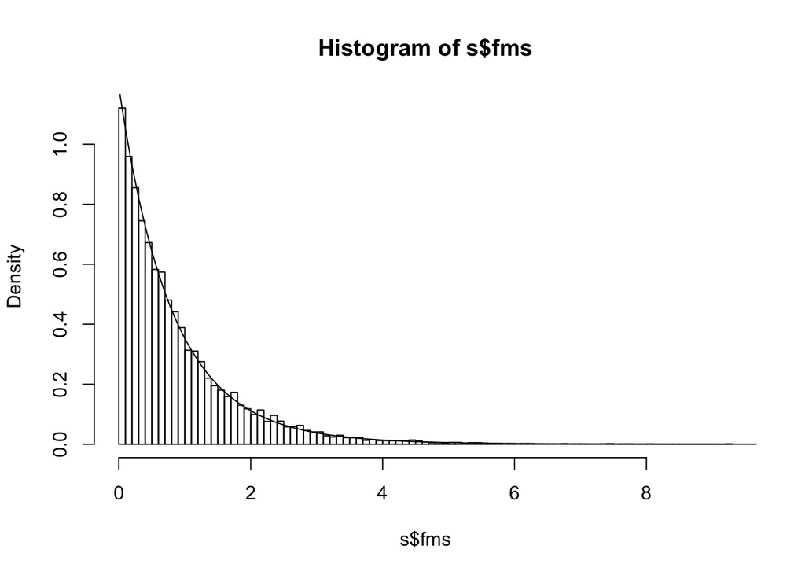

```r
btdd = 10
g_fs <- function(t,mu,r,s){   ## g of first missing speciation
  rate = s*(1-exp(-mu*(r-t)))
  int = s*(t-(exp(-r*mu)/mu)*(exp(t*mu)-1))
  prob = rate*exp(-int)
  return(prob)
}
btdd=10
pars = c(1,0.1,30)
m=10000
time = seq(0,btdd[1],by=0.1)
s = sim.sct(btdd,pars,m=m,print = F)
prob = sum(is.na(s$fms))/m
g = g_fs(time,mu=pars[2],r=btdd[1],s=2*(pars[1]-(pars[1]-pars[2])*2/pars[3]))/(1-prob)
hist(s$fms,prob=TRUE,breaks = 80)
lines(time,g)
```

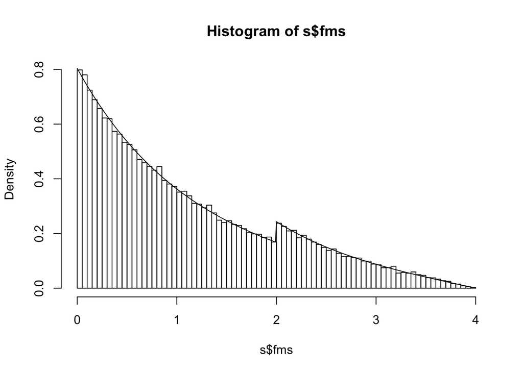

```r
# with one shift

g_fs2 <- function(t,mu,r,s,bk){   ## g of first missing speciation
  if(t<bk){
    rate = s*(1-exp(-mu*(r-t)))
    int = s*(t-(exp(-r*mu)/mu)*(exp(t*mu)-1))
    prob = rate*exp(-int)
  }else{
    int1 = s*(bk-(exp(-r*mu)/mu)*(exp(bk*mu)-1))
    s2=3*(pars[1]-(pars[1]-pars[2])*3/pars[3])
    rate = s2*(1-exp(-mu*(r-t)))
    int2 = s2*(t-bk-(exp(-r*mu)/mu)*(exp(t*mu)-exp(bk*mu)))
    prob = rate*exp(-int1)*exp(-int2)
  }
  return(prob)
}

m= 100000
btdd = c(4,2)
s = sim.sct(btdd,pars,m=m,print = F)
time = seq(0,btdd[1],by=0.01)
i=1
g = NULL
for(ti in time){
  g[i] = g_fs2(ti,mu=pars[2],r=btdd[1],s=2*(pars[1]-(pars[1]-pars[2])*2/pars[3]),bk=btdd[2])
  i = i+1
}

prob = sum(is.na(s$fms))/m
g = g/(1-prob)
hist(s$fms,prob=TRUE,breaks = 80)
lines(time,g)
```